# Final Project

Kearon Chase

Due: 12/17/2019

## How does player position and performance affect team success?

```r
library(DataComputing)
library(party)
library(partykit)
tbl <- read.csv(file = 'nba.csv')
tbl2 <- read.csv(file = 'nba_extra.csv')
head(tbl)
```

```
##   Rk                   Player Pos Age  Tm  G   MP  PER   TS. X3PAr   FTr
## 1  1  Alex Abrines\\abrinal01  SG  24 OKC 75 1134  9.0 0.567 0.759 0.158
## 2  2      Quincy Acy\\acyqu01  PF  27 BRK 70 1359  8.2 0.525 0.800 0.164
## 3  3  Steven Adams\\adamsst01   C  24 OKC 76 2487 20.6 0.630 0.003 0.402
## 4  4   Bam Adebayo\\adebaba01   C  20 MIA 69 1368 15.7 0.570 0.021 0.526
## 5  5 Arron Afflalo\\afflaar01  SG  32 ORL 53  682  5.8 0.516 0.432 0.160
## 6  6  Cole Aldrich\\aldrico01   C  29 MIN 21   49  6.0 0.340 0.000 0.400
##   ORB. DRB. TRB. AST. STL. BLK. TOV. USG.  X  OWS DWS  WS  WS.48 X.1 OBPM
## 1  2.5  8.9  5.6  3.4  1.7  0.6  7.4 12.7 NA  1.3 1.0 2.2  0.094  NA -0.5
## 2  3.1 17.0 10.0  6.0  1.2  1.6 13.3 14.4 NA -0.1 1.1 1.0  0.036  NA -2.0
## 3 16.6 13.9 15.3  5.5  1.8  2.8 13.2 16.7 NA  6.7 3.0 9.7  0.187  NA  2.2
## 4  9.7 21.6 15.6 11.0  1.2  2.5 13.6 15.9 NA  2.3 1.9 4.2  0.148  NA -1.6
## 5  0.6 10.1  5.3  6.2  0.3  1.1 10.8 12.5 NA -0.1 0.2 0.1  0.009  NA -4.1
## 6  7.0 28.6 17.7  8.2  2.0  1.8  5.4 16.8 NA -0.1 0.1 0.0 -0.013  NA -7.0
##   DBPM  BPM VORP
## 1 -1.7 -2.2 -0.1
## 2 -0.2 -2.2 -0.1
## 3  1.1  3.3  3.3
## 4  1.8  0.2  0.8
## 5 -1.8 -5.8 -0.7
## 6  0.1 -6.9 -0.1
```

```r
head(tbl2)
```

```
##   Rk                   Player Pos Age  Tm  G GS   MP  FG FGA   FG. X3P
## 1  1  Alex Abrines\\abrinal01  SG  24 OKC 75  8 1134 115 291 0.395  84
## 2  2      Quincy Acy\\acyqu01  PF  27 BRK 70  8 1359 130 365 0.356 102
## 3  3  Steven Adams\\adamsst01   C  24 OKC 76 76 2487 448 712 0.629   0
## 4  4   Bam Adebayo\\adebaba01   C  20 MIA 69 19 1368 174 340 0.512   0
## 5  5 Arron Afflalo\\afflaar01  SG  32 ORL 53  3  682  65 162 0.401  27
## 6  6  Cole Aldrich\\aldrico01   C  29 MIN 21  0   49   5  15 0.333   0
##   X3PA  X3P. X2P X2PA  X2P.  eFG.  FT FTA   FT. ORB DRB TRB AST STL BLK
## 1  221 0.380  31   70 0.443 0.540  39  46 0.848  26  88 114  28  38   8
## 2  292 0.349  28   73 0.384 0.496  49  60 0.817  40 217 257  57  33  29
## 3    2 0.000 448  710 0.631 0.629 160 286 0.559 384 301 685  88  92  78
## 4    7 0.000 174  333 0.523 0.512 129 179 0.721 118 263 381 101  32  41
## 5   70 0.386  38   92 0.413 0.485  22  26 0.846   4  62  66  30   4   9
## 6    0    NA   5   15 0.333 0.333   2   6 0.333   3  12  15   3   2   1
##   TOV  PF  PTS
## 1  25 124  353
## 2  60 149  411
## 3 128 215 1056
## 4  66 138  477
## 5  21  56  179
## 6   1  11   12
```

```r
new_tbl <-
  tbl %>%
  select(Player, Pos, Age, PER, TS., X3PAr, BPM, USG., OWS) %>%
  left_join(tbl2  %>% select(c("Player", "MP", "FG", "X3P.", "X2P.", "eFG.", "PTS", "TOV", "BLK", "ORB")), by = c("Player" = "Player"))
head(new_tbl)
```

```
##                     Player Pos Age  PER   TS. X3PAr  BPM USG.  OWS   MP
## 1  Alex Abrines\\abrinal01  SG  24  9.0 0.567 0.759 -2.2 12.7  1.3 1134
## 2      Quincy Acy\\acyqu01  PF  27  8.2 0.525 0.800 -2.2 14.4 -0.1 1359
## 3  Steven Adams\\adamsst01   C  24 20.6 0.630 0.003  3.3 16.7  6.7 2487
## 4   Bam Adebayo\\adebaba01   C  20 15.7 0.570 0.021  0.2 15.9  2.3 1368
## 5 Arron Afflalo\\afflaar01  SG  32  5.8 0.516 0.432 -5.8 12.5 -0.1  682
## 6  Cole Aldrich\\aldrico01   C  29  6.0 0.340 0.000 -6.9 16.8 -0.1   49
##    FG  X3P.  X2P.  eFG.  PTS TOV BLK ORB
## 1 115 0.380 0.443 0.540  353  25   8  26
## 2 130 0.349 0.384 0.496  411  60  29  40
## 3 448 0.000 0.631 0.629 1056 128  78 384
## 4 174 0.000 0.523 0.512  477  66  41 118
## 5  65 0.386 0.413 0.485  179  21   9   4
## 6   5    NA 0.333 0.333   12   1   1   3
```

This code joins the two data sources, selecting column that are related to my research question and could be used.

```r
target <- c("PG", "SG", "SF", "PF", "C")
new_tbl<-new_tbl %>%
  filter(Pos %in% target)

total_pos <- new_tbl %>%
  group_by(Pos) %>%
  summarise(total = n())
head(total_pos)
```

```
## # A tibble: 5 x 2
##   Pos   total
##   <fct> <int>
## 1 C       192
## 2 PF      176
## 3 PG      234
## 4 SF      197
## 5 SG      248
```

```r
non_guards <- new_tbl %>%
  group_by(Pos) %>%
  filter(grepl("[^G]$", Pos))
#head(non_guards)

guards <- new_tbl %>%
  group_by(Pos) %>%
  filter(grepl("[G]$", Pos))
#head(non_guards)

prime_talent_guards <- guards %>%
  group_by(Age) %>%
  filter(19<Age) %>%
  filter(Age <= 33)
head(prime_talent_guards)
```

```
## # A tibble: 6 x 18
## # Groups:   Age [5]
##   Player  Pos     Age   PER   TS. X3PAr   BPM  USG.   OWS    MP    FG  X3P.
##   <fct>   <fct> <int> <dbl> <dbl> <dbl> <dbl> <dbl> <dbl> <int> <int> <dbl>
## 1 "Alex … SG       24   9   0.567 0.759  -2.2  12.7   1.3  1134   115 0.38
## 2 "Arron… SG       32   5.8 0.516 0.432  -5.8  12.5  -0.1   682    65 0.386
## 3 "Kadee… PG       25   2.6 0.366 0.5    -6.4  14.6  -0.2   107     6 0
## 4 "Ryan … PG       23   7.3 0.55  0.756  -4.1   8.1   0.1   304    17 0.290
## 5 "Jamel… SG       25   6.9 0.457 0.367  -5.9  14.5  -0.1   279    31 0.276
## 6 "D.J. … PG       30  15.4 0.615 0.504  -0.9  18.6   3.3  1760   244 0.419
## # … with 6 more variables: X2P. <dbl>, eFG. <dbl>, PTS <int>, TOV <int>,
## #   BLK <int>, ORB <int>
```

```r
non_guard_prime_talent <- non_guards %>%
  group_by(Age) %>%
  filter(19<Age) %>%
  filter(Age <= 33)
head(non_guard_prime_talent)
```

```
## # A tibble: 6 x 18
## # Groups:   Age [5]
##   Player Pos     Age   PER   TS. X3PAr   BPM  USG.   OWS    MP    FG   X3P.
##   <fct>  <fct> <int> <dbl> <dbl> <dbl> <dbl> <dbl> <dbl> <int> <int>  <dbl>
## 1 "Quin… PF       27   8.2 0.525 0.8    -2.2  14.4  -0.1  1359   130  0.349
## 2 "Stev… C        24  20.6 0.63  0.003   3.3  16.7   6.7  2487   448  0
## 3 "Bam … C        20  15.7 0.570 0.021   0.2  15.9   2.3  1368   174  0
## 4 "Cole… C        29   6   0.34  0      -6.9  16.8  -0.1    49     5 NA
## 5 "LaMa… C        32  25   0.570 0.068   3.3  29.1   7.4  2509   687  0.293
## 6 "Al-F… PF       27  12   0.522 0.582   1.1  14.8   0.9  2072   230  0.369
## # … with 6 more variables: X2P. <dbl>, eFG. <dbl>, PTS <int>, TOV <int>,
## #   BLK <int>, ORB <int>
```

What I am doing here is first filtering the original table to eliminate players with multiple positions because some of these people are re-listed. Secondly, i gathered the total number of players represented for each position. This allowed me to see if any position was being misrepresented with a low sample size. This ended up not being the case as the distribution of postions is relativley normal. Next, i used regular expressions to create a table of only non-guards. I did this because guards are often the most popular positions that general basektball fans are enamoured with and create many false-narratives about guards being the mosts important to championship success. Additionally, because guards tend to have the ball in there hands the most, they will skew the averages so this counteracts that. Laastly, i created the two tables i wil use mostly throughout this evaluation by filtering players younger than 20 and older than 33 because they are historically unproductive, with the exception of players like Lebron James, Kevin Durant, and players of that caliber.

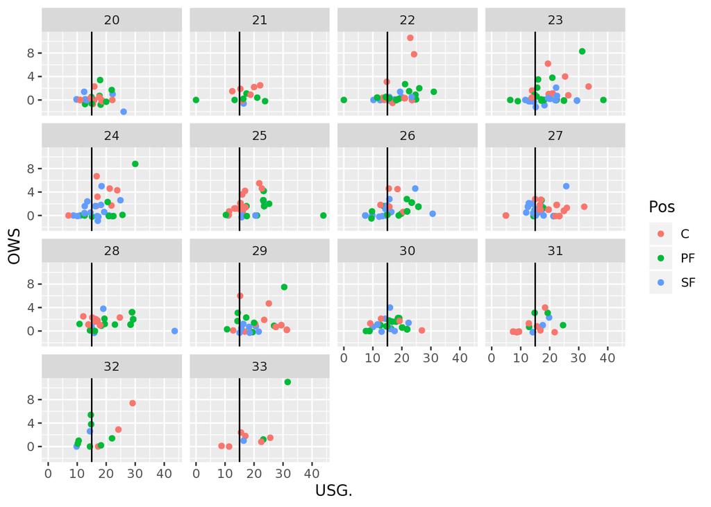

```r
usg_ows_ng<-ggplot(data=non_guard_prime_talent,aes(x=USG.,y=OWS))+geom_point()+aes(colour=Pos)+facet_wrap(~Age,ncol=4) + geom_vline(xintercept = 15)
usg_ows_g<- ggplot(data=prime_talent_guards,aes(x=USG.,y=OWS))+geom_point()+aes(colour=Pos)+facet_wrap(~Age,ncol=4) + geom_vline(xintercept = 15)

g_ts_pm <- ggplot(data=prime_talent_guards,aes(x=TS.,y=BPM))+geom_point() + geom_hline(yintercept = 0)
ng_or_ows <- ggplot(data=non_guard_prime_talent,aes(x=ORB,y=OWS))+geom_point()

usg_ows_ng
```